# IE 360 Project / Group 14

*Dürdane Karabacak, Yunus Emre Karataş, Halenur Kocaman, Merve Gülsüm Kıratlı, Merve Keskin*

6 July 2020

## INTRODUCTION

Forecasting the sales quantity of a product for an online retail is a challenging task. Forecasting heavily relies on the historical data and your modeling skills. In this project, forecasting methods are developed to predict the next day’s sales quantity of 8 products sold in Trendyol. The products are La Roche Posay Facial Cleanser, Sleepy Wet Towel, Xiaomi Bluetooth Headphone, Fakir Sweeper, Trendyolmilla Tight Trousers, Oral-B Re-chargeable Toothbrush, Trendyolmilla Bikini Top and Koton Coat.

After manipulating the data, literature review is made and several models are used to forecast product sales. In this project Sarima, Sarimax, Naive Forecasts, Arima, Error Prediction with Arima, ETS and Error Prediction with ETS are used which will be explained in detail in Approach part.

Between these models, the one with the best cross validation score is selected and submitted. Each group’s performance is measured by “Weighted Mean Absolute Percentage Error” (WMAPE) of their prediction. The lower the WMAPE score the better the prediction.

## RELATED LITERATURE

Broadly speaking, in Time Series Modeling and Forecasting article by Adhikari and Agrawal [1], they have presented a state-of-the-art of some popular time series forecasting models such as ARIMA models for linear time series forecasting with their salient features. This article has been seen that, the proper selection of the model orders (in case of ARIMA), the number of inputs, hidden and output neurons and the constant hyper-parameters is extremely crucial for successful forecasting. Moreover, the one important function, AIC, is discussed which are frequently used for ARIMA model selection. For selecting the number of constant hyper-parameters (different p, d and q parameters used in our term project), cross validation should be carried out. Furthermore, a few important performance measures for evaluating the accuracy of forecasting models are considered in this article. To be able to obtain a reasonable knowledge about the overall forecasting error, more than one measure should be used in practice. Because of this reason, using different data sets, and different performance measures for models is an important satisfactory way.

On the other hand, in some cases, significant deviation can be seen among the original observations and the forecasted values. In such cases, a suitable data preprocessing, other than those used in the work may improve the forecast performances.

## APPROACH

The data for each product is split into train and test set. To find the best predictive model, 6 different modelling approaches are used. Among these alternatives the model with the smallest MAPE score in the test set is used to make the daily predictions.

#### ARIMA

The first model tried is an ARIMA model. Regressors are not used in this model. To find the best seasonal parameter (m), different m values up to 13 are examined in a for loop. In the for loop, auto arima function is used in the test set. By doing this, the best ARIMA model is found for this specific seasonality case. Auto arima gives the model with the smallest AIC for the specific m value. After the model find the best models for each m value, these models are compared to each other. Model with the smallest AIC value is selected. Then the selected model is used to make forecasts. To be able to compare different models, MAPE score is calculated using the test set. The advantage of the model is being fast. However, the model’s prediction power is not high since explanatory regressors are not used.

#### ARIMAX

This model tries to forecast sales using time series data and additional regressors. To understand the regressors affecting the sales, linear regression is applied. The significant parameters are used as regressors in ARIMAX model. Seasonality is neglected in this model because the regressors such as day of month, weekday are used to determine the seasonality effect. The for loop used in the previous model to find the best m value is not used in this model.

#### ARIMAX using Cross Validation

The third model is an ARIMA model. In this ARIMA model, model parameters p,d,q are found with cross validation in train set. Different p,d,q values are tried to find the best model:

• p=”0”,”1”,”2”,”3”

• d=”0”,”1”

• q=”0”,”1”,”2”,”3”

#### Regression + Residual Modelling with ARIMA using Cross Validation

Since the regression is used previously to find the significant features, it can be used to predict the sales demand. However, its residuals should be normally distributed. Moreover, since its residuals are also a time series data, it can be modeled with ARIMA or SARIMA model. Then, the prediction from regression and the prediction from time series residuals modelling are added to predict the corresponding sales demand. By doing that, 3 different trend alternative, “c”, “t” and “ct” are added to the grid search, and therefore parameter space consists of 96 different alternatives. They are evaluated in the train set with the cross-validation perspective and the best possible model is evaluated in the test set. Later, the MAPE score of this approach is recorded to compare with the other models.

#### ETS models using Cross Validation

Since ETS (error,trend,seasonality) models can also be used with univariate time series data,the sales demand is modeled without the regressors. Different t,s,p values are tried to find the best model:

• t = ['add', 'mul']

• s = ['add', 'mul']

• p = [2,3,4,7,12]

where t,s and p correspond to trend component, seasonality component and the seasonality period respectively.

Cross validation is used to find the best model among the alternatives and MAPE score of the best model is recorded.

#### Residual modelling with ETS approach using Cross Validation

Since ETS models require univariate time series data, it performs poorly compared to the other approaches. Therefore, residuals from regression model are used also as a univariate time series data and it is modeled with different t,s,p alternatives. The best model is found using cross validation in the train data and it is used to predict the residuals. These predictions are combined with the regression predictios to achieve the demand sales prediction for the test set. Then the MAPE score in the test set is recorded.

## RESULTS

In this part of the report, submissions that are made during the project will be given. As described in the previous section, we have six different forecasting models for making predictions. After we constructed those models, we performed several analysis on test data. Initially, we made predictions for those six models and calculated MAPE values for different models. Then, the best model giving the least MAPE value is selected for submission for each day.

[figure not shown]

## CONCLUSION

For data preprocessing, sold_count mean of each product are calculated and if sold_count mean is greater than 5, then missing values are not considering otherwise they are taken. Some other preprocessing steps are as follow:

• High missing rate columns are dropped. (If missing_rate > 50%)

• Missing dates are added to the dataset.

• Low missing rate columns are filled by using linear interpolation.

For time series modeling, WMAPE values, which are the performance criterion of all methods, are calculated. When we compare the WMAPE for each model, it can be understood that using there is no best model to give best forecast prediction for all products but for every single product, one time series model is selected to make best prediction of sales quantity.

For future works, cross relations between products can be considering. This could lead to clusters of products that behave coherently. The idea comes from that, some products are complementary to another ones, so considering cross relation between sales relation of products may increase accuracy of our time series sales quantity forecast results. The principle of this study can be used in the real application of e-commerce companies to predict the sales of various forms of products. Depending on the sales frequency of different types of products, different forecasting models can be selected to use this more effective to predict sales in a future period. Therefore, according to this precise forecast, the enterprise's inventory strategy and logistics strategy can be more rationally formulated so that the entire supply chain can operate more smoothly.

## Reference

Adhikari, Ratnadip & Agrawal, R.. (2013). An Introductory Study on Time series Modeling and Forecasting. 10.13140/2.1.2771.8084.

## CODE

```python
import pandas as pd
import numpy as np
import json
import matplotlib.pyplot as plt
import statsmodels.api as sm
from statsmodels.tsa.api import ExponentialSmoothing
from pmdarima.model_selection import SlidingWindowForecastCV
import pmdarima as pm
from pmdarima import arima
from pmdarima import utils
import time
import datetime
from pmdarima import model_selection
from scipy import stats
import requests
import json
import datetime
```

```python
calendar_data=pd.read_csv("calendar2.csv",sep=";")

#GÜNCELLE HER GÜNN
f=open('10.json',)
data = json.load(f)
data = pd.DataFrame.from_dict(data)
data["event_date"] = pd.to_datetime(data["event_date"])
data = data.sort_values(by=["event_date"])
data=data.set_index("event_date")
data.loc[:,"product_content_id"] = pd.to_numeric(data.product_content_id)
data=data.replace(-1,np.nan)
```

```python
data.tail(8)
```

| event_date | price | product_content_id | sold_count | visit_count | favored_count | basket_count | category_sold | category_brand_sold | category_visits | ty_visits |
| --- | --- | --- | --- | --- | --- | --- | --- | --- | --- | --- |
| 2020-06-09 | 76.05 | 85004 | 40 | 1687 | 127 | 167 | 3631.0 | 196.0 | 265482.0 | 116963774.0 |
| 2020-06-09 | 128.09 | 32939029 | 16 | 1521 | 62 | 86 | 872.0 | 806.0 | 76363.0 | 116963774.0 |
| 2020-06-09 | 228.87 | 7061886 | 26 | 1207 | 57 | 98 | 435.0 | 118.0 | 87539.0 | 116963774.0 |
| 2020-06-09 | 74.13 | 4066298 | 192 | 2361 | 69 | 327 | 1118.0 | 499.0 | 34096.0 | 116963774.0 |
| 2020-06-09 | NaN | 3904356 | 0 | 1 | 0 | 0 | 620.0 | 7.0 | 324604.0 | 116963774.0 |
| 2020-06-09 | 44.99 | 31515569 | 721 | 23043 | 744 | 4175 | 8499.0 | 1948.0 | 810713.0 | 116963774.0 |
| 2020-06-09 | NaN | 5926527 | 0 | 178 | 5 | 4 | 2668.0 | 2259.0 | 486140.0 | 116963774.0 |
| 2020-06-09 | 137.98 | 6676673 | 491 | 15845 | 236 | 1635 | 3048.0 | 673.0 | 367276.0 | 116963774.0 |

```python
calendar_data=pd.read_csv("calendar2.csv",sep=";")
```

```python
calendar_data.head()
```

|  | calendar_date_id | calendar_date | calendar_month | calendar_day | calendar_year | calendar_quarter | calendar_period | day_of_week | day_of_week_in_month | day_of_week_in_year | ... | first_date_of_quarter | last_date_of_quarter | first_date_of_year | last_date_of_year | is_weekday | is_business_day | is_holiday | holiday_name | ramadan_flag | formula |
| --- | --- | --- | --- | --- | --- | --- | --- | --- | --- | --- | --- | --- | --- | --- | --- | --- | --- | --- | --- | --- | --- |
| 0 | 20130101 | 2013-01-01 00:00:00.000 | 1 | 1 | 2013 | 1 | 12 | 2 | 1 | 1 | ... | 2013-01-01 00:00:00.000 | 2013-03-31 00:00:00.000 | 2013-01-01 00:00:00.000 | 2013-12-31 00:00:00.000 | 1 | 1 | 1 | 1 Ocak YılBaşı | NaN | NaN |
| 1 | 20130102 | 2013-01-02 00:00:00.000 | 1 | 2 | 2013 | 1 | 12 | 3 | 1 | 1 | ... | 2013-01-01 00:00:00.000 | 2013-03-31 00:00:00.000 | 2013-01-01 00:00:00.000 | 2013-12-31 00:00:00.000 | 1 | 1 | 0 | NaN | NaN | NaN |
| 2 | 20130103 | 2013-01-03 00:00:00.000 | 1 | 3 | 2013 | 1 | 12 | 4 | 1 | 1 | ... | 2013-01-01 00:00:00.000 | 2013-03-31 00:00:00.000 | 2013-01-01 00:00:00.000 | 2013-12-31 00:00:00.000 | 1 | 1 | 0 | NaN | NaN | NaN |
| 3 | 20130104 | 2013-01-04 00:00:00.000 | 1 | 4 | 2013 | 1 | 12 | 5 | 1 | 1 | ... | 2013-01-01 00:00:00.000 | 2013-03-31 00:00:00.000 | 2013-01-01 00:00:00.000 | 2013-12-31 00:00:00.000 | 1 | 1 | 0 | NaN | NaN | NaN |
| 4 | 20130105 | 2013-01-05 00:00:00.000 | 1 | 5 | 2013 | 1 | 12 | 6 | 1 | 1 | ... | 2013-01-01 00:00:00.000 | 2013-03-31 00:00:00.000 | 2013-01-01 00:00:00.000 | 2013-12-31 00:00:00.000 | 1 | 1 | 0 | NaN | NaN | NaN |

5 rows × 31 columns

## Data from GOOGLE-TRENDS

```python
trendyol_hepsiburada=pd.read_csv("data_klasörü/trendyol_hepsi.csv",skiprows=2)
trendyol_hepsiburada.columns=["Hafta","trendyol","hepsiburada"]

trendyol_hepsiburada.Hafta=pd.to_datetime(trendyol_hepsiburada.Hafta)
trendyol_hepsiburada.set_index("Hafta",inplace=True)
merged_2=trendyol_hepsiburada.copy()
merged_2.tail()
```

| Hafta | trendyol | hepsiburada |
| --- | --- | --- |
| 2020-04-26 | 19 | 39 |
| 2020-05-03 | 22 | 43 |
| 2020-05-10 | 21 | 44 |
| 2020-05-17 | 17 | 38 |
| 2020-05-24 | 16 | 34 |

```python
calendar_data.calendar_date=pd.to_datetime(calendar_data.calendar_date)
calendar_data=calendar_data[(calendar_data.calendar_date>pd.to_datetime("2019-04-29"))]
calendar_data=calendar_data.loc[:,calendar_data.columns.tolist()[1:17]+calendar_data.columns.tolist()[25:-1]]
calendar_data.drop(["holiday_name","calendar_year"],1,inplace=True)
calendar_data=calendar_data.set_index("calendar_date").fillna(0)
calendar_data.drop(["calendar_quarter","calendar_period","days_in_month","week_of_quarter"],1,inplace=True)
calendar_data.head()
```

| calendar_date | calendar_month | calendar_day | day_of_week | day_of_week_in_month | day_of_week_in_year | day_of_week_in_quarter | day_of_quarter | day_of_year | week_of_month | week_of_year | is_weekday | is_business_day | is_holiday | ramadan_flag |
| --- | --- | --- | --- | --- | --- | --- | --- | --- | --- | --- | --- | --- | --- | --- |
| 2019-04-30 | 4 | 30 | 2 | 5 | 18 | 5 | 30 | 120 | 5 | 18 | 1 | 1 | 0 | 0.0 |
| 2019-05-01 | 5 | 1 | 3 | 1 | 18 | 5 | 31 | 121 | 1 | 18 | 1 | 1 | 1 | 0.0 |
| 2019-05-02 | 5 | 2 | 4 | 1 | 18 | 5 | 32 | 122 | 1 | 18 | 1 | 1 | 0 | 0.0 |
| 2019-05-03 | 5 | 3 | 5 | 1 | 18 | 5 | 33 | 123 | 1 | 18 | 1 | 1 | 0 | 0.0 |
| 2019-05-04 | 5 | 4 | 6 | 1 | 18 | 5 | 34 | 124 | 1 | 18 | 1 | 1 | 0 | 0.0 |

### Merge Datasets

```python
merged_x=data.merge(calendar_data,how="left",left_index=True,right_index=True)
merged_all=merged_x.copy()
merged_all=merged_x.merge(merged_2,how="left",left_index=True,right_index=True)
```

```python
merged_all[["trendyol","hepsiburada"]]=merged_all[["trendyol","hepsiburada"]].ffill().bfill()
merged_all[["trendyol","hepsiburada"]].tail(20)
```

|  | trendyol | hepsiburada |
| --- | --- | --- |
| 2020-06-07 | 16.0 | 34.0 |
| 2020-06-07 | 16.0 | 34.0 |
| 2020-06-07 | 16.0 | 34.0 |
| 2020-06-07 | 16.0 | 34.0 |
| 2020-06-08 | 16.0 | 34.0 |
| 2020-06-08 | 16.0 | 34.0 |
| 2020-06-08 | 16.0 | 34.0 |
| 2020-06-08 | 16.0 | 34.0 |
| 2020-06-08 | 16.0 | 34.0 |
| 2020-06-08 | 16.0 | 34.0 |
| 2020-06-08 | 16.0 | 34.0 |
| 2020-06-08 | 16.0 | 34.0 |
| 2020-06-09 | 16.0 | 34.0 |
| 2020-06-09 | 16.0 | 34.0 |
| 2020-06-09 | 16.0 | 34.0 |
| 2020-06-09 | 16.0 | 34.0 |
| 2020-06-09 | 16.0 | 34.0 |
| 2020-06-09 | 16.0 | 34.0 |
| 2020-06-09 | 16.0 | 34.0 |
| 2020-06-09 | 16.0 | 34.0 |

## DIVIDE THE DATA FOR EACH PRODUCT

```python
merged_all=merged_x.copy()
```

```python
merged_all.columns
```

```
Index(['price', 'product_content_id', 'sold_count', 'visit_count',
       'favored_count', 'basket_count', 'category_sold', 'category_brand_sold',
       'category_visits', 'ty_visits', 'calendar_month', 'calendar_day',
       'day_of_week', 'day_of_week_in_month', 'day_of_week_in_year',
       'day_of_week_in_quarter', 'day_of_quarter', 'day_of_year',
       'week_of_month', 'week_of_year', 'is_weekday', 'is_business_day',
       'is_holiday', 'ramadan_flag'],
      dtype='object')
```

```python
merged_all.product_content_id.unique().tolist()
```

```
[4066298, 31515569, 7061886, 3904356, 85004, 6676673, 5926527, 32939029]
```

```python
product_df_list=[]
product_list=merged_all.product_content_id.unique().tolist()
for product in product_list:
    product_df_list.append(merged_all[merged_all.product_content_id==product])
```

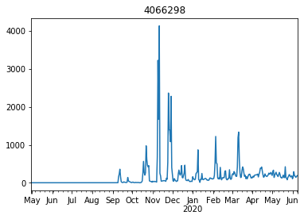

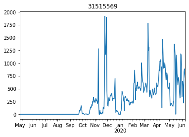

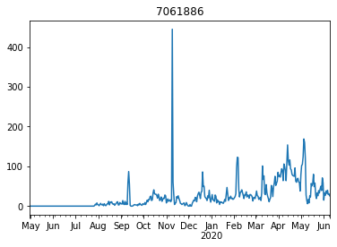

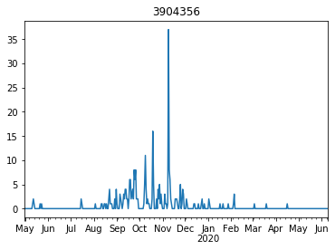

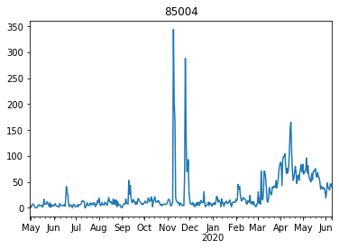

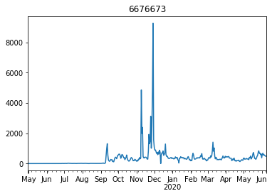

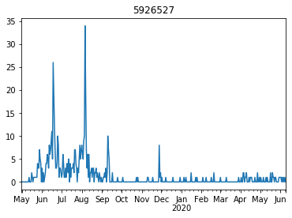

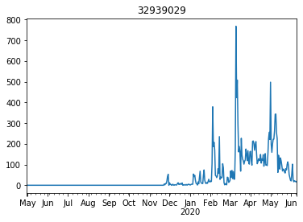

```python
for i in range(len(product_list)):
    plt.figure()
    product_df_list[i].sold_count.plot(title=product_list[i])
    #product_df_list[i]= product_df_list[i].loc["2020.01.01":]
```

```python
product_df_list[0]
```

|  | price | product_content_id | sold_count | visit_count | favored_count | basket_count | category_sold | category_brand_sold | category_visits | ty_visits | ... | day_of_week_in_year | day_of_week_in_quarter | day_of_quarter | day_of_year | week_of_month | week_of_year | is_weekday | is_business_day | is_holiday | ramadan_flag |
| --- | --- | --- | --- | --- | --- | --- | --- | --- | --- | --- | --- | --- | --- | --- | --- | --- | --- | --- | --- | --- | --- |
| 2019-04-30 | NaN | 4066298 | 0 | 0 | 0 | 0 | 3.0 | NaN | NaN | NaN | ... | 18 | 5 | 30 | 120 | 5 | 18 | 1 | 1 | 0 | 0.0 |
| 2019-05-01 | NaN | 4066298 | 0 | 0 | 0 | 0 | NaN | NaN | NaN | NaN | ... | 18 | 5 | 31 | 121 | 1 | 18 | 1 | 1 | 1 | 0.0 |
| 2019-05-02 | NaN | 4066298 | 0 | 0 | 0 | 0 | 1.0 | NaN | NaN | NaN | ... | 18 | 5 | 32 | 122 | 1 | 18 | 1 | 1 | 0 | 0.0 |
| 2019-05-03 | NaN | 4066298 | 0 | 0 | 0 | 0 | 4.0 | NaN | NaN | NaN | ... | 18 | 5 | 33 | 123 | 1 | 18 | 1 | 1 | 0 | 0.0 |
| 2019-05-04 | NaN | 4066298 | 0 | 0 | 0 | 0 | 3.0 | NaN | NaN | NaN | ... | 18 | 5 | 34 | 124 | 1 | 18 | 1 | 1 | 0 | 0.0 |
| ... | ... | ... | ... | ... | ... | ... | ... | ... | ... | ... | ... | ... | ... | ... | ... | ... | ... | ... | ... | ... | ... |
| 2020-06-05 | 73.26 | 4066298 | 173 | 2185 | 85 | 304 | 1345.0 | 437.0 | 43081.0 | 99383334.0 | ... | 23 | 10 | 66 | 157 | 1 | 23 | 1 | 1 | 0 | 0.0 |
| 2020-06-06 | 73.17 | 4066298 | 143 | 1942 | 67 | 292 | 1091.0 | 386.0 | 35895.0 | 105029842.0 | ... | 23 | 10 | 67 | 158 | 1 | 23 | 1 | 1 | 0 | 0.0 |
| 2020-06-07 | 73.21 | 4066298 | 156 | 1767 | 55 | 235 | 1020.0 | 391.0 | 26588.0 | 97486477.0 | ... | 23 | 10 | 68 | 159 | 2 | 23 | 0 | 0 | 0 | 0.0 |
| 2020-06-08 | 73.60 | 4066298 | 185 | 2493 | 60 | 354 | 1167.0 | 520.0 | 34408.0 | 103702694.0 | ... | 23 | 10 | 69 | 160 | 2 | 24 | 0 | 0 | 0 | 0.0 |
| 2020-06-09 | 74.13 | 4066298 | 192 | 2361 | 69 | 327 | 1118.0 | 499.0 | 34096.0 | 116963774.0 | ... | 23 | 10 | 70 | 161 | 2 | 24 | 1 | 1 | 0 | 0.0 |

407 rows × 24 columns

## PREPROCESSING

##### REMOVE HIGH MISSING COLUMNS

##### FILL THE VALUES IN COLUMNS WITH LOW MISSING RATIO

```python
processed_df_train_list=[]
#processed_df_test_list=[]

#REMOVE HIGH MISSING VALUE COLUMNS
for i in range(len(product_df_list)):
    print(product_list[i])
    print("********************")
    prod_1=product_df_list[i]
    prod_1.drop("product_content_id",1,inplace=True)

        #print(prod_1.index.max())
    if (prod_1.sold_count.mean()>5):
        print("meanli:",product_list[i])
        if prod_1.sold_count[-1]==0:
            prod_1.sold_count[-1]=prod_1.sold_count[-2]
        prod_1=prod_1[prod_1.sold_count!=0]

    removed_columns=prod_1.columns[(prod_1.isnull().sum()/prod_1.shape[0])>0.5].tolist()
    print("column with missing value higher than %50 are:",removed_columns)
    prod_1.drop(removed_columns,1,inplace=True) #drop
    if(prod_1.isnull().sum().sum()>0):
        print("for missing value included products:",prod_1.isnull().sum().sum())
        print(product_list[i])
        print(prod_1.isnull().sum())
        prod_1=prod_1.interpolate()# for now linear interpolation

    idx = pd.date_range(prod_1.index.min(), prod_1.index.max())
    prod_1=prod_1.reindex(idx)
    #print(prod_1.index[(prod_1.reindex(idx).isnull().sum(axis=1)>0)].tolist())

    prod_1=prod_1.ffill().bfill()
    print("in the end,missing values:",prod_1.isnull().sum().sum())
    print("************************")
    #train, test = pm.model_selection.train_test_split(prod_1, train_size=0.8)
    #processed_df_train_list.append(train)
    processed_df_train_list.append(prod_1)
    #processed_df_test_list.append(test)
```

```
4066298
meanli: 4066298
column with missing value higher than %50 are: []
for missing value included products: 270
4066298
price                       0
sold_count                  0
visit_count                 0
favored_count               0
basket_count                0
category_sold               0
category_brand_sold         0
category_visits           135
ty_visits                 135
calendar_month              0
calendar_day                0
day_of_week                 0
day_of_week_in_month        0
day_of_week_in_year         0
day_of_week_in_quarter      0
day_of_quarter              0
day_of_year                 0
week_of_month               0
week_of_year                0
is_weekday                  0
is_business_day             0
is_holiday                  0
ramadan_flag                0
dtype: int64
in the end,missing values: 0
31515569
meanli: 31515569
column with missing value higher than %50 are: []
for missing value included products: 230
31515569
price                       0
sold_count                  0
visit_count                 0
favored_count               0
basket_count                0
```

[output cut: 97 more lines]

```
calendar_day               0
day_of_week                0
day_of_week_in_month       0
day_of_week_in_year        0
day_of_week_in_quarter     0
day_of_quarter             0
day_of_year                0
week_of_month              0
week_of_year               0
is_weekday                 0
is_business_day            0
is_holiday                 0
ramadan_flag               0
dtype: int64
in the end,missing values: 0
```

```python
for i in range(len(processed_df_train_list)):
    if ((processed_df_train_list[i].index.max()-processed_df_train_list[i].index.min()).days+1 == processed_df_train_list[i].shape[0]):
        print("for product ",product_list[i],"no missing days")
    else:
        print("for product ",product_list[i], " missing days exist")
```

```
for product  4066298 no missing days
for product  31515569 no missing days
for product  7061886 no missing days
for product  3904356 no missing days
for product  85004 no missing days
for product  6676673 no missing days
for product  5926527 no missing days
for product  32939029 no missing days
```

# FEATURE ENGINEERING

Select the significant features by looking at its p-value in the regression

If trim regression model( model with all features have p-value less than 0.10) have a better AIC, remove other columns

Else use all features because its model (full_model) gives the better AIC

```python
#prod_1=prod_1.loc[:,(np.abs(prod_1.corr()["sold_count"]).values)>0.10]
reg_models=[]
train_dfs=[]
test_dfs=[]
for i in range(len(processed_df_train_list)):
    print((product_list[i]))
    prod_1_X=processed_df_train_list[i].drop("sold_count",1)
    prod_1_y=(processed_df_train_list[i].sold_count)
    #prod_1_X=sm.add_constant(prod_1_X)


    reg_obj=sm.OLS(prod_1_y,prod_1_X).fit()

    prod_1_X_trimmed=prod_1_X.iloc[:,(reg_obj.pvalues<0.10).values]
    reg_obj_final=sm.OLS(prod_1_y,prod_1_X_trimmed).fit()


    test_dfs.append(prod_1_y)
    print("R2 values for normal and trim models are:",reg_obj.rsquared_adj,reg_obj_final.rsquared_adj)
    print("AIC values for normal and trim models are:",reg_obj.aic,reg_obj_final.aic)
    if(reg_obj_final.aic<reg_obj.aic):
        my_reg=reg_obj_final
        my_df=prod_1_X_trimmed
        reg_models.append(my_reg)
        train_dfs.append(my_df)

    else:
        my_reg=reg_obj
        my_df=prod_1_X
        reg_models.append(my_reg)
        train_dfs.append(my_df)
```

```
4066298
R2 values for normal and trim models are: 0.8862560278118043 0.8891807857933542
AIC values for normal and trim models are: 3599.433264582855 3579.024040499121
31515569
R2 values for normal and trim models are: 0.919893228279516 0.9110953463762147
AIC values for normal and trim models are: 3427.3241424678736 3441.419868019124
7061886
R2 values for normal and trim models are: 0.952737168089637 0.9522302110029077
AIC values for normal and trim models are: 2444.1723582956643 2440.93366104322
3904356
R2 values for normal and trim models are: 0.8577657760096058 0.853577020255553
AIC values for normal and trim models are: 1120.8845903749748 1122.0467954247965
85004
R2 values for normal and trim models are: 0.8475548734448435 0.8474140838781921
AIC values for normal and trim models are: 3475.290078381288 3466.0225796739023
6676673
R2 values for normal and trim models are: 0.8604276442246134 0.863242391842735
AIC values for normal and trim models are: 5081.987410878654 5064.169157227751
5926527
R2 values for normal and trim models are: 0.7192579774786716 0.7110599255290377
AIC values for normal and trim models are: 1671.5006433060125 1669.6057665036947
32939029
R2 values for normal and trim models are: 0.9651278693028043 0.9649069478417296
AIC values for normal and trim models are: 1878.1658821212857 1871.9863779279572
```

```python
product_list
```

```
[4066298, 31515569, 7061886, 3904356, 85004, 6676673, 5926527, 32939029]
```

```python
for i in range(len(product_list)):
    train_dfs[i].to_csv(str(product_list[i]))
```

# VISUALIZE THE DATA

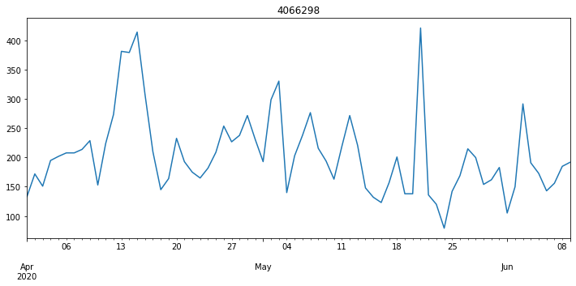

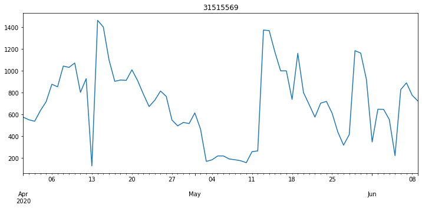

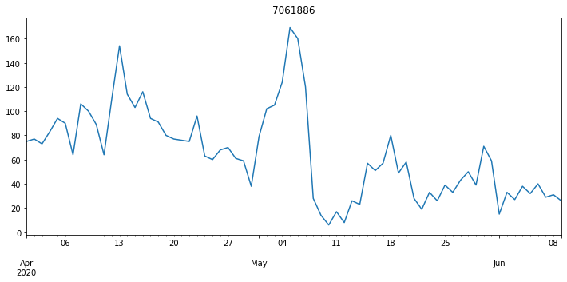

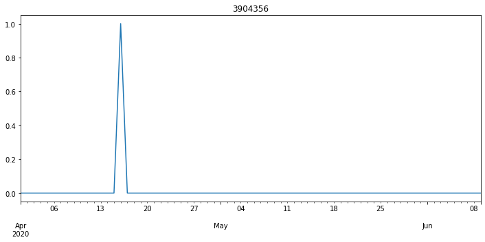

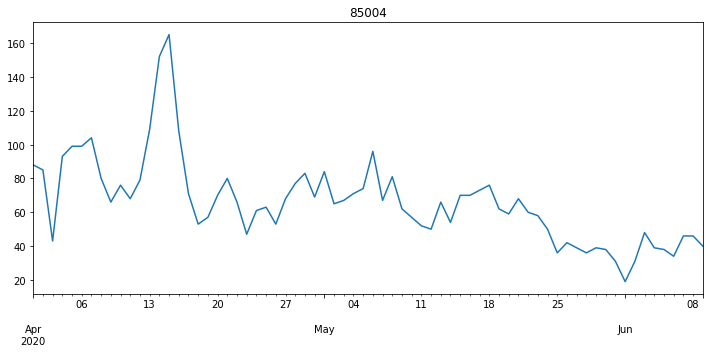

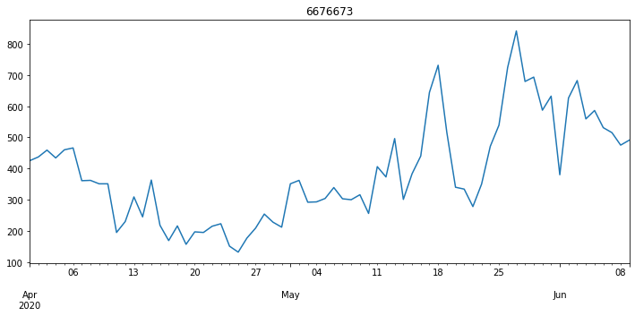

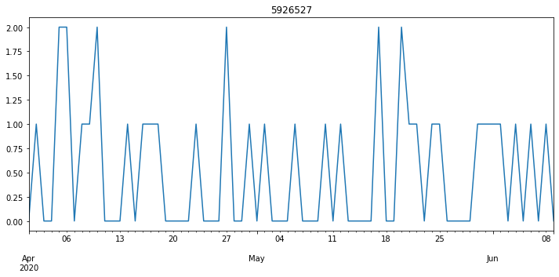

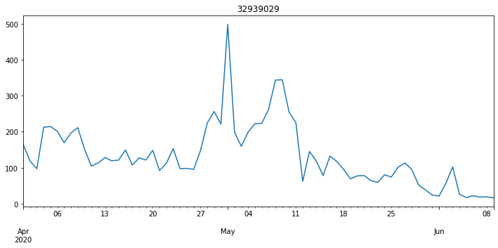

```python
for i in range(len(product_list)):
    plt.figure(figsize=(12,5))
    processed_df_train_list[i].loc["2020-04-01":].sold_count.plot(title=product_list[i])
```

- Autocorrelation - The autocorrelation function (ACF) measures how a series is correlated with itself at different lags.
- Partial Autocorrelation - The partial autocorrelation function can be interpreted as a regression of the series against its past lags. The terms can be interpreted the same way as a standard linear regression, that is the contribution of a change in that particular lag while holding others constant.

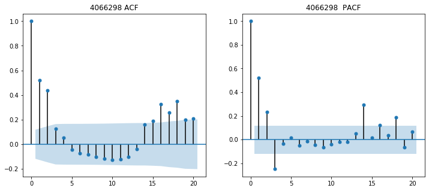

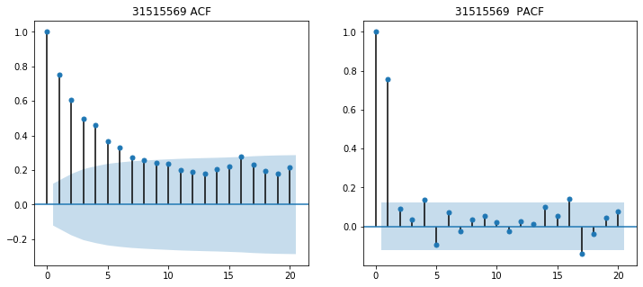

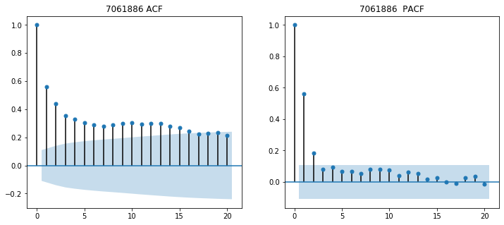

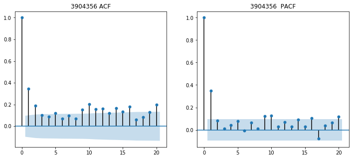

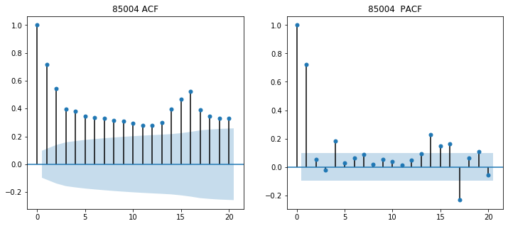

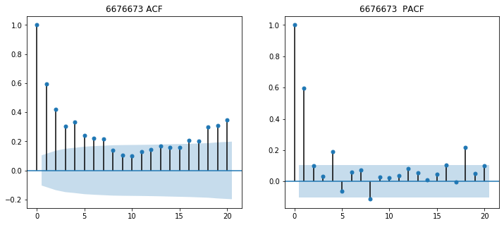

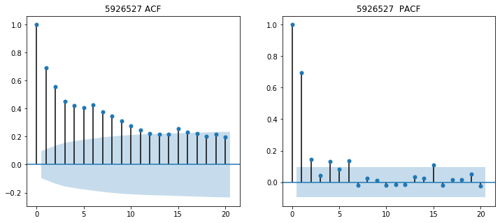

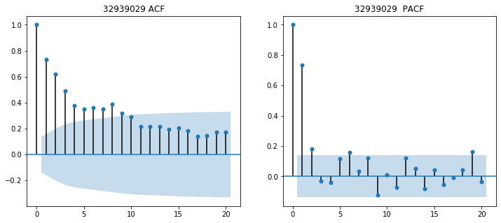

```python
import statsmodels.api as sm
for i in range(len(product_list)):
    fig,ax=plt.subplots(1,2,sharex=True,figsize=(12,5))
    figure=sm.graphics.tsa.plot_acf(processed_df_train_list[i].sold_count, lags=20,title=str(product_list[i])+" ACF",ax=ax[0])
    figure2=sm.graphics.tsa.plot_pacf(processed_df_train_list[i].sold_count, lags=20,title=str(product_list[i])+"  PACF",ax=ax[1])
    plt.show()
```

### Decomposition Plots to see Trend and Seasonality Better

```
for product 4066298
```

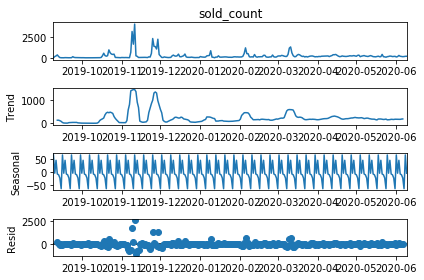

```
for product 31515569
```

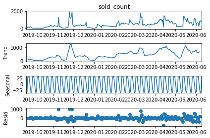

```
for product 7061886
```

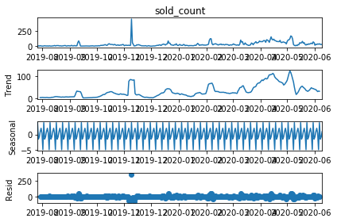

```
for product 3904356
```

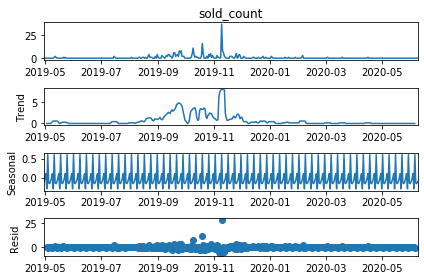

```
for product 85004
```

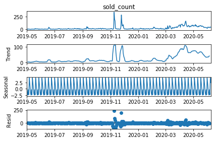

```
for product 6676673
```

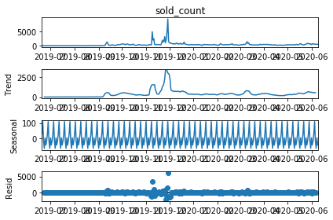

```
for product 5926527
```

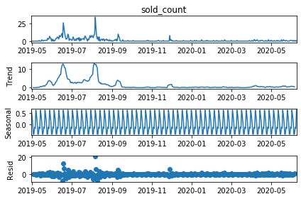

```
for product 32939029
```

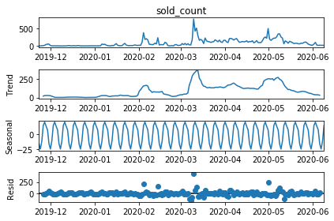

```python
trend_seasonal_removed_ts_list=[]
for i in range(len(product_list)):
    print("for product", product_list[i])
    print("*************************")

    decomposed = sm.tsa.seasonal_decompose(test_dfs[i])
    decomposed.plot()
    plt.show()
    trend_seasonal_removed_ts=decomposed.resid
    trend_seasonal_removed_ts_list.append(trend_seasonal_removed_ts)
```

```python
test_dfs[-1]
```

```
2019-11-23     6.0
2019-11-24     2.0
2019-11-25     8.0
2019-11-26     8.0
2019-11-27    20.0
              ...
2020-06-05    17.0
2020-06-06    22.0
2020-06-07    18.0
2020-06-08    19.0
2020-06-09    16.0
Freq: D, Name: sold_count, Length: 200, dtype: float64
```

```python
#Get residuals from regression to model later
```

```python
ts_residuals=[]
for i in range(len(reg_models)):
    print(reg_models[i].summary())
    ts_residuals.append(reg_models[i].resid)
```

```
                                 OLS Regression Results
=======================================================================================
Dep. Variable:             sold_count   R-squared (uncentered):                   0.892
Model:                            OLS   Adj. R-squared (uncentered):              0.889
Method:                 Least Squares   F-statistic:                              316.2
Date:                Wed, 10 Jun 2020   Prob (F-statistic):                   1.46e-125
Time:                        10:53:23   Log-Likelihood:                         -1782.5
No. Observations:                 275   AIC:                                      3579.
Df Residuals:                     268   BIC:                                      3604.
Df Model:                           7
Covariance Type:            nonrobust
==================================================================================
                     coef    std err          t      P>|t|      [0.025      0.975]
----------------------------------------------------------------------------------
visit_count        0.0886      0.011      8.276      0.000       0.068       0.110
favored_count      1.0631      0.333      3.188      0.002       0.407       1.720
calendar_month  2031.3903    523.855      3.878      0.000     999.995    3062.786
calendar_day      66.7393     17.294      3.859      0.000      32.690     100.788
day_of_week     -228.9626     56.959     -4.020      0.000    -341.107    -116.818
day_of_year      160.5758     39.555      4.060      0.000      82.698     238.454
week_of_year   -1598.2542    398.844     -4.007      0.000   -2383.521    -812.987
==============================================================================
Omnibus:                      338.934   Durbin-Watson:                   1.649
Prob(Omnibus):                  0.000   Jarque-Bera (JB):            58614.189
Skew:                           4.971   Prob(JB):                         0.00
Kurtosis:                      73.828   Cond. No.                     2.83e+05
==============================================================================

Warnings:
[1] Standard Errors assume that the covariance matrix of the errors is correctly specified.
[2] The condition number is large, 2.83e+05. This might indicate that there are
strong multicollinearity or other numerical problems.
                                 OLS Regression Results
=======================================================================================
Dep. Variable:             sold_count   R-squared (uncentered):                   0.926
Model:                            OLS   Adj. R-squared (uncentered):              0.920
Method:                 Least Squares   F-statistic:                              144.3
Date:                Wed, 10 Jun 2020   Prob (F-statistic):                   1.25e-123
Time:                        10:53:23   Log-Likelihood:                         -1692.7
No. Observations:                 262   AIC:                                      3427.
```

[output cut: 234 more lines]

```
calendar_day               8.6628      0.900      9.621      0.000       6.887      10.439
day_of_week_in_year      -59.7837      6.491     -9.210      0.000     -72.587     -46.981
day_of_week_in_quarter    67.7309      8.389      8.074      0.000      51.185      84.277
day_of_quarter           -10.1095      1.195     -8.462      0.000     -12.466      -7.753
==============================================================================
Omnibus:                       41.981   Durbin-Watson:                   1.112
Prob(Omnibus):                  0.000   Jarque-Bera (JB):              331.315
Skew:                          -0.458   Prob(JB):                     1.14e-72
Kurtosis:                       9.238   Cond. No.                     8.11e+04
==============================================================================

Warnings:
[1] Standard Errors assume that the covariance matrix of the errors is correctly specified.
[2] The condition number is large, 8.11e+04. This might indicate that there are
strong multicollinearity or other numerical problems.
```

```python
def sarima_configs(index=None):
    models = list()
    # define config lists
    p_params = [0,1,2,3]
    d_params = [0, 1]
    q_params = [0,1,2,3]
    t_params = ['c','t','ct']

    # create config instances
    if index=="sarimax":
        print("for sarimax")
        for p in p_params:
            for d in d_params:
                for q in q_params:
                    cfg = (p,d,q)
                    models.append(cfg)
    else:
        for p in p_params:
            for d in d_params:
                for q in q_params:
                    for t in t_params:

                        cfg = [(p,d,q), t]
                        models.append(cfg)
    return models
```

```python
def sarima_forecast(data,config,exog=None):

    try:
        order, trend = config
        print(config)
        model = pm.ARIMA(order=order,trend=trend, enforce_stationarity=False, enforce_invertibility=False,suppress_warnings=True)
    except:
        order = config
        print(config)
        model = pm.ARIMA(order=order, enforce_stationarity=False, enforce_invertibility=False,suppress_warnings=True)

    cv = SlidingWindowForecastCV(window_size=int(len(data)*0.95),h=2)

    if isinstance(exog,pd.DataFrame):
        model_cv_scores=pm.model_selection.cross_val_score(model, data, exog,scoring='smape', cv=cv)
    else:
        model_cv_scores=pm.model_selection.cross_val_score(model, data,scoring='smape', cv=cv)
    model_error=np.mean(model_cv_scores)

    return model_error,model
```

```python
# create a set of exponential smoothing configs to try
def exp_smoothing_configs(seasonal=[None]):
    models = list()
    # define config lists
    t_params = ['add', 'mul']

    s_params = ['add', 'mul']
    p_params = [2,3,4,7,12]



    # create config instances
    for t in t_params:

        for s in s_params:
            for p in p_params:
                cfg = [t,s,p]
                models.append(cfg)
    return models

def exp_model(data,config):

    errors=[]
    cv = SlidingWindowForecastCV(window_size=int(len(data)*0.95),h=2)#change
    cv_generator = cv.split(data)
    error_total=0
    counter=0
    for train_index,test_index in (cv_generator):

        t,s,p = config

        try:
            model = ExponentialSmoothing(data[train_index], trend=t,seasonal=s,seasonal_periods=int(p),freq="D")
            model_fit=model.fit()
            #print("actual is:",data[test].values)
            pred=model_fit.forecast(2).values #change
            #print("pred is:",pred)

            error=np.abs((data[test_index].values-pred)/(data[test_index].values))
            #print("error is:",np.mean(error))
            error_total+=np.mean(error)
            counter+=1

        except:
            return None,10**6

    mape=error_total/counter

    return model,mape
```

## MODELLING

```python
product_list
```

```
[4066298, 31515569, 7061886, 3904356, 85004, 6676673, 5926527, 32939029]
```

```python
pred_dict={}
```